# Chapter 5 Exercises - Bayes Rules!

## Exercise 5.1

For each situation below, tune an appropriate Gamma( $s, r$ ) prior model for $\lambda$.

### (a) The most common value of $\lambda$ is 4, and the mean is 7.

**Solution**  
We are given that the **mode** of $\lambda$ is 4 and the **mean** is $7$. Using the formulas for the mean and mode of the Gamma distribution, we can solve for the shape $s$ and rate $r$:

- The **mean** is $\mu = \frac{s}{r}$, so $s = 7r$.
- The **mode** is $\text{mode} = \frac{s - 1}{r}$, so substituting $s = 7r$ into this equation:
  $$4 = \frac{7r - 1}{r} \quad \Rightarrow \quad 4r = 7r - 1 \quad
  \Rightarrow \quad r = \frac{1}{3}.$$

Substituting $r = \frac{1}{3}$ into $s = 7r$:
$$s = \frac{7}{3}.$$

### (b) The most common value of $\lambda$ is 10 and the mean is 12.

**Solution**  
In this case, we are given the **mode** of $\lambda$ is 10 and the **mean** $\mu$ is 12. Using the same method as in part (a), we solve for $s$ and $r$:

- The **mean** is:
  $$\mu = \frac{s}{r}, \quad \Rightarrow \quad s = 12r$$
- The **mode** is:
  $$\text{mode} = \frac{s - 1}{r} \quad \Rightarrow \quad 10 = \frac{12r -
  1}{r}.$$

  Solving for $r$:
  $$10r = 12r - 1 \quad \Rightarrow \quad r = \frac{1}{2}.$$

Substituting $r = \frac{1}{2}$ back into $s = 12r$:
$$s = 6.$$

### (c) The most common value of $\lambda$ is 5, and the variance is 3.

**Solution**
To calculate $s$ and $r$, we start with the **variance** and **mode** formulas for the Gamma distribution. The **variance** is:
$$\sigma^2 = \frac{s}{r^2}, \quad \Rightarrow \quad s = 3r^2.$$

The **mode** is:
$$\text{mode} = \frac{s - 1}{r}.$$
Substituting $s = 3r^2$ into this equation, and solving for $r$, we get:
$$3r^2 - 5r - 1 = 0.$$
We can solve the quadratic equation using the quadratic formula:

```r
a = 3
b = -5
c = -1

# solution 1: using the negative root
r0 = (-b - sqrt(b^2 - 4 * a * c)) / (2 * a)
s0 = 3 * r0 ^ 2
s0
```

```
## [1] 0.09769789
```

```r
r0
```

```
## [1] -0.1804604
```

```r
# solution 2: using the positive root
r1 = (-b + sqrt(b^2 - 4 * a * c)) / (2 * a)
s1 = 3 * r1 ^ 2
s1
```

```
## [1] 10.23564
```

```r
r1
```

```
## [1] 1.847127
```

Since the negative root does not lead to an admissible value for the rate parameter., the shape and rate are given by the solution to the positive root.

#### (d) The most common value of $\lambda$ is 14, and the variance is 6.

**Solution**
To calculate $s$ and $r$, we start with the **variance** and **mode** formulas for the Gamma distribution. The **variance** is:
$$\sigma^2 = \frac{s}{r^2} \quad \Rightarrow \quad s = 6r^2$$

The **mode** is:
$$\text{mode} = \frac{s - 1}{r}.$$
Substituting $s = 6r^2$ into this equation and solving for $r$, we get:
$$14r = 6r^2 - 1 \quad \Rightarrow \quad 6r^2 - 14r - 1 = 0.$$
We can solve the quadratic equation using the quadratic formula:

```r
a = 6
b = -14
c = -1

# solution 1: negative root
r0 = (-b - sqrt(b^2 - 4 * a * c)) / (2 * a)
s0 = 6 * r0 ^ 2
s0
```

```
## [1] 0.0288702
```

```r
r0
```

```
## [1] -0.06936641
```

```r
# solution 2: positive root
r1 = (-b + sqrt(b^2 - 4 * a * c)) / (2 * a)
s1 = 6 * r1 ^ 2
s1
```

```
## [1] 34.6378
```

```r
r1
```

```
## [1] 2.4027
```

Since the negative root does not lead to an admissible value for the rate parameter, the shape and rate are given by the solution to the positive root.

### (e) The mean of $\lambda$ is 4 and the variance is 12.

**Solution**  
In this case, we are given the **mean** $\mu = 4$ and **variance** $\sigma^2 = 12$. Using the **mean** and **variance** formulas for the Gamma distribution:

- The **mean** is:
  $$\mu = \frac{s}{r} \quad \Rightarrow \quad s = 4r$$
- The **variance** is:
  $$\text{variance} = \frac{s}{r^2} \quad \Rightarrow \quad s = 12r^2$$

Now, solving the system of equations $s = 4r$ and $s = 12r^2$, we find $r = \frac{1}{3}$ and $s = \frac{4}{3}$.

### (f) The mean of $\lambda$ is 22 and the variance is 3.

**Solution**  
In this case, we are given the **mean** $\mu = 22$ and **variance** $\sigma^2 = 3$. Using the **mean** and **variance** formulas for the Gamma distribution:

- The **mean** is:
  $$\mu = \frac{s}{r} \quad \Rightarrow \quad s = 22r$$
- The **variance** is:
  $$\text{variance} = \frac{s}{r^2} \quad \Rightarrow \quad s = 3r^2$$

Now, solving the system of equations $s = 22r$ and $s = 3r^2$, we find $r = \frac{22}{3}$ and $s = \frac{484}{3}$.

## Exercise 5.2

For each situation below, we observe the outcomes for a random sample of Poisson variables,  
$Y_i | \lambda \overset{\text{ind}}{\sim} \text{Pois}(\lambda)$. Specify and plot the likelihood function of $\lambda$.

#### (a) $(y_1, y_2, y_3) = (3, 7, 19)$

**Solution**  
We will plot the likelihood function for this dataset using the Poisson distribution. The likelihood is calculated for different values of $\lambda$.

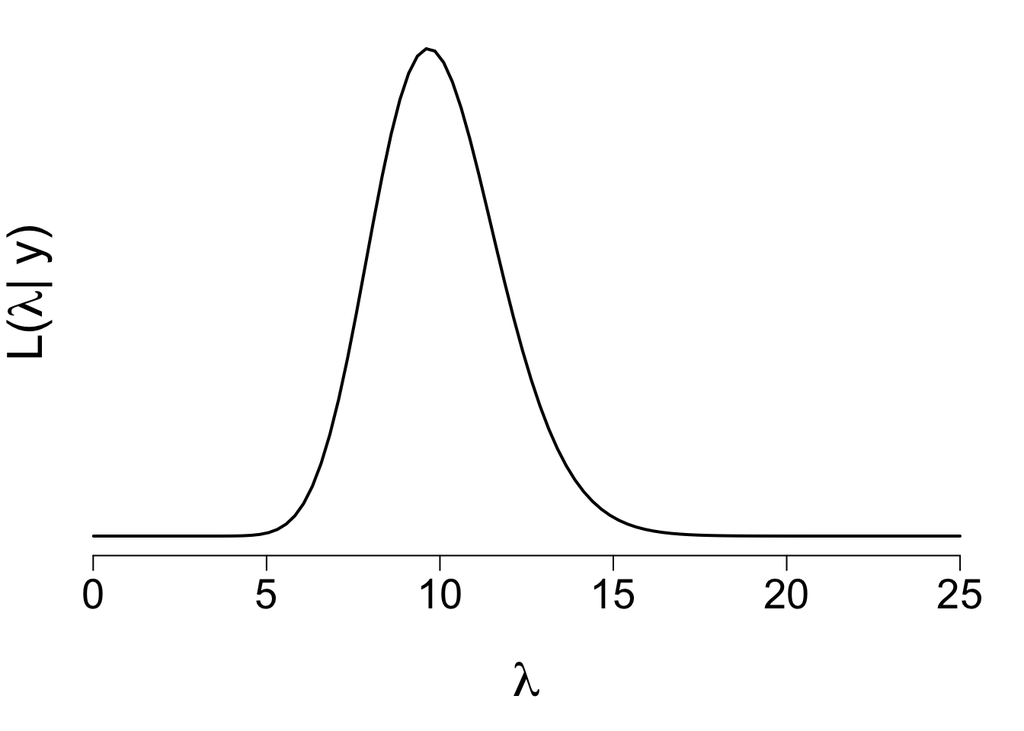

```r
# Given data
y = c(3, 7, 19)

# Define the range of lambda values
L = seq(0.01, 25, length.out = 100)

# Calculate the likelihood for each lambda
likelihood = sapply(L, function(l) {
  prod(dpois(y, lambda = l))
})

# Plot the likelihood function
par(mar = c(6, 2, 1, 1), las = 1)
plot(L, likelihood, type = "l", axes = FALSE, xlab = "", ylab = "", xlim = c(0, 25), lwd = 2)
mtext(expression(lambda), side = 1, line = 4, cex = 2)
mtext(expression(paste("L(", lambda, "| y)")), side = 2, line = 0, cex = 2, las = 0)
axis(1, cex.axis = 1.7)
```

#### (b) $(y_1, y_2, y_3, y_4) = (12, 12, 12, 0)$

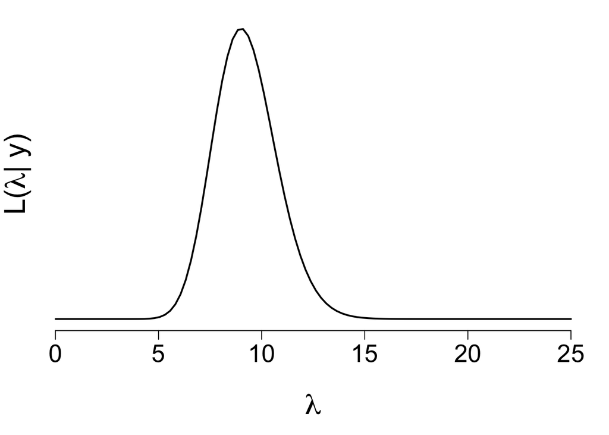

```r
# Given data
y = c(12, 12, 12, 0)

# Calculate the likelihood for each lambda
likelihood = sapply(L, function(l) {
  prod(dpois(y, lambda = l))
})

# Plot the likelihood function
par(mar = c(6, 2, 1, 1), las = 1)
plot(L, likelihood, type = "l", axes = FALSE, xlab = "", ylab = "", xlim = c(0, 25), lwd = 2)
mtext(expression(lambda), side = 1, line = 4, cex = 2)
mtext(expression(paste("L(", lambda, "| y)")), side = 2, line = 0, cex = 2, las = 0)
axis(1, cex.axis = 1.7)
```

#### (c) $y_1 = 12$

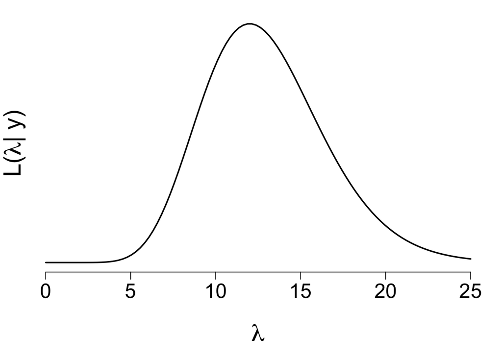

```r
# Given data
y = c(12)

# Calculate the likelihood for each lambda
likelihood = sapply(L, function(l) {
  prod(dpois(y, lambda = l))
})

# Plot the likelihood function
par(mar = c(6, 2, 1, 1), las = 1)
plot(L, likelihood, type = "l", axes = FALSE, xlab = "", ylab = "", xlim = c(0, 25), lwd = 2)
mtext(expression(lambda), side = 1, line = 4, cex = 2)
mtext(expression(paste("L(", lambda, "| y)")), side = 2, line = 0, cex = 2, las = 0)
axis(1, cex.axis = 1.7)
```

#### (d) $(y_1, y_2, y_3, y_4, y_5) = (16, 10, 17, 11, 11)$

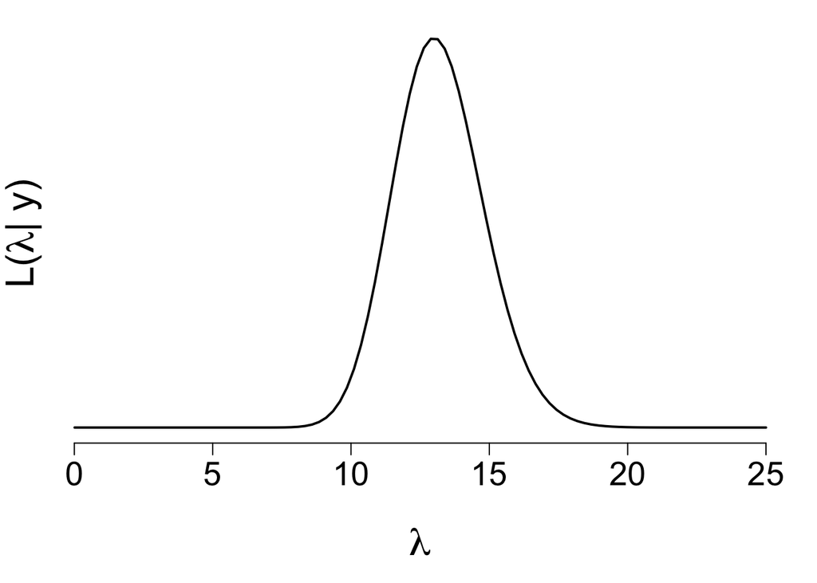

```r
# Given data
y = c(16, 10, 17, 11, 11)

# Calculate the likelihood for each lambda
likelihood = sapply(L, function(l) {
  prod(dpois(y, lambda = l))
})

# Plot the likelihood function
par(mar = c(6, 2, 1, 1), las = 1)
plot(L, likelihood, type = "l", axes = FALSE, xlab = "", ylab = "", xlim = c(0, 25), lwd = 2)
mtext(expression(lambda), side = 1, line = 4, cex = 2)
mtext(expression(paste("L(", lambda, "| y)")), side = 2, line = 0, cex = 2, las = 0)
axis(1, cex.axis = 1.7)
```

## Exercise 5.3

Assume a prior model of $\lambda \sim \text{Gamma}(24, 2)$. Specify the posterior models of $\lambda$ corresponding to the data in each scenario of Exercise 5.2.

**Solution**

We are given that the **Gamma prior** is $\lambda \sim \text{Gamma}(24, 2)$, where $s_0 = 24$ and $r_0 = 2$. Since the likelihood for $\lambda$ is a **Poisson distribution**, we find a **Gamma posterior**:
$$\lambda | y \sim \text{Gamma}(s_0 + \sum_i y_i, r_0 + n),$$
where $\sum_iy_i$ is the sum of the data points and $n$ is the number of observations. We can now calculate the posterior parameters $s_1,r_1$ for each scenario:

1. $s_1 = 53$ and $r_1=5$
2. $s_1 = 60$ and $r_1=6$
3. $s_1 = 36$ and $r_1=3$
4. $s_1 = 89$ and $r_1=7$

## Exercise 5.7

Let $\lambda$ be the average number of goals scored in a Women’s World Cup game. We’ll analyze $\lambda$ by the following Gamma-Poisson model where data $Y_i$ is the observed number of goals scored in a sample of World Cup games:

$Y_i | \lambda \overset{\text{ind}}{\sim} \text{Pois}(\lambda)$

$\lambda \sim \text{Gamma}(1, 0.25)$

1. Plot and summarize our prior understanding of $\lambda$.

**Solution:**

We are given a **Gamma prior** for $\lambda$, where the **shape** $s = 1$ and the **rate** $r = \frac{1}{4}$. First, we will plot the prior distribution.

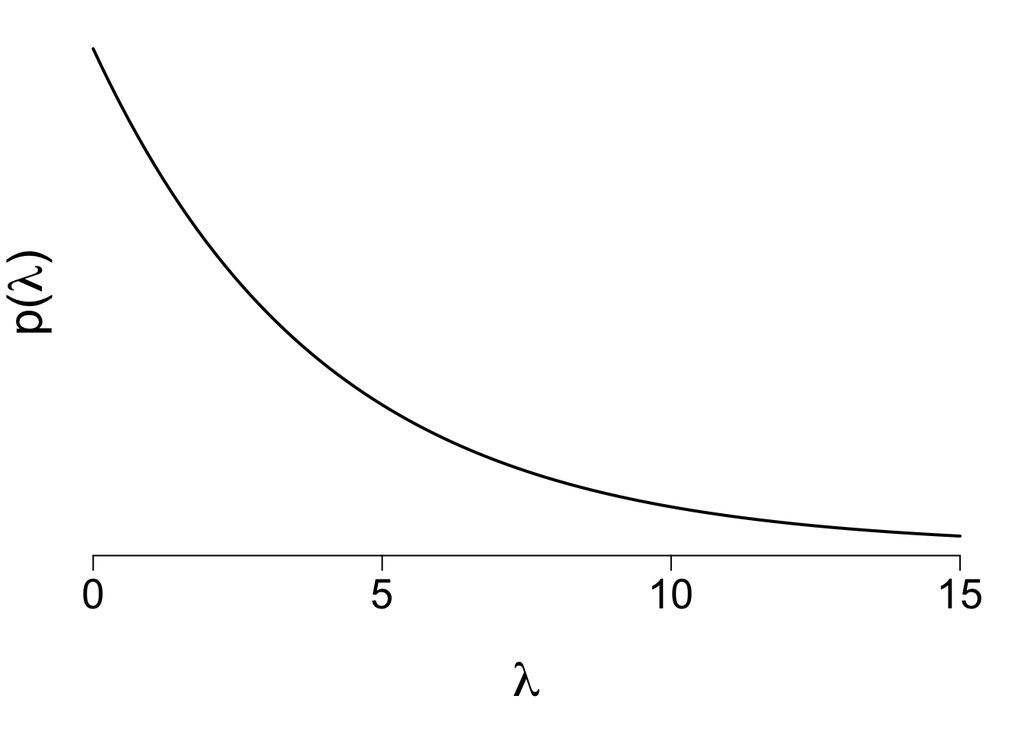

```r
# Define prior parameters
s = 1
r = 1/4

# Generate lambda values
L = seq(0, 15, length.out = 100)

# Plot the prior distribution
par(mar = c(6, 2, 1, 1), las = 1)
plot(L, dgamma(L, shape = s, rate = r), type = "l", axes = FALSE,
     xlab = "", ylab = "", xlim = c(0, 15),
     lwd = 2)
mtext(expression(lambda), side = 1, line = 4, cex = 2)
mtext(expression(paste("p(", lambda, ")")), side = 2, line = 0, cex = 2, las = 0)
axis(1, cex.axis= 1.7)
```

We expect that $4$ goals will be scored, on average, while it is much more plausible to have games with less than $4$ goals, there is room for more!

2. Why is the Poisson model a reasonable choice for our data $Y_i$?

**Solution:** We are given a count variable with a few successes.

3. The `wwc_2019_matches` data in the `fivethirtyeight` package includes the number of goals scored by the two teams in each 2019 Women’s World Cup match. Define, plot, and discuss the total number of goals scored per game:

```r
library(fivethirtyeight)
data("wwc_2019_matches")
wwc_2019_matches <- wwc_2019_matches %>% mutate(total_goals = score1 + score2)
```

4. Identify the posterior model of $\lambda$ and verify your answer using `summarize_gamma_poisson()`.

**Solution:** We are using the **Women’s World Cup 2019** data from the `fivethirtyeight` package, which contains the number of goals scored by the two teams in each match. The goal is to update our **Gamma prior** to compute the **posterior**.

```r
# Load the WWC 2019 data
library(fivethirtyeight)
data("wwc_2019_matches")

# Total goals scored in each game
x = wwc_2019_matches$score1 + wwc_2019_matches$score2

# Calculate updated shape and rate for posterior
s_post = s + sum(x)
r_post = r + length(x)

# Display posterior parameters
s_post
```

```
## [1] 147
```

```r
r_post
```

```
## [1] 52.25
```

```r
# Using bayesrules package to summarize Gamma-Poisson posterior
library(bayesrules)
summarize_gamma_poisson(shape = s, rate = r, sum_y = sum(x), n = length(x))
```

```
##       model shape  rate     mean     mode         var        sd
## 1     prior     1  0.25 4.000000 0.000000 16.00000000 4.0000000
## 2 posterior   147 52.25 2.813397 2.794258  0.05384492 0.2320451
```

5. Plot the prior pdf, likelihood function, and posterior pdf of $\lambda$. Describe the evolution in your understanding of $\lambda$ from the prior to the posterior.

**Solution** Next, we will plot the **prior**, **likelihood**, and **posterior** distributions for $\lambda$. This provides a visual understanding of how the data updates our prior beliefs.

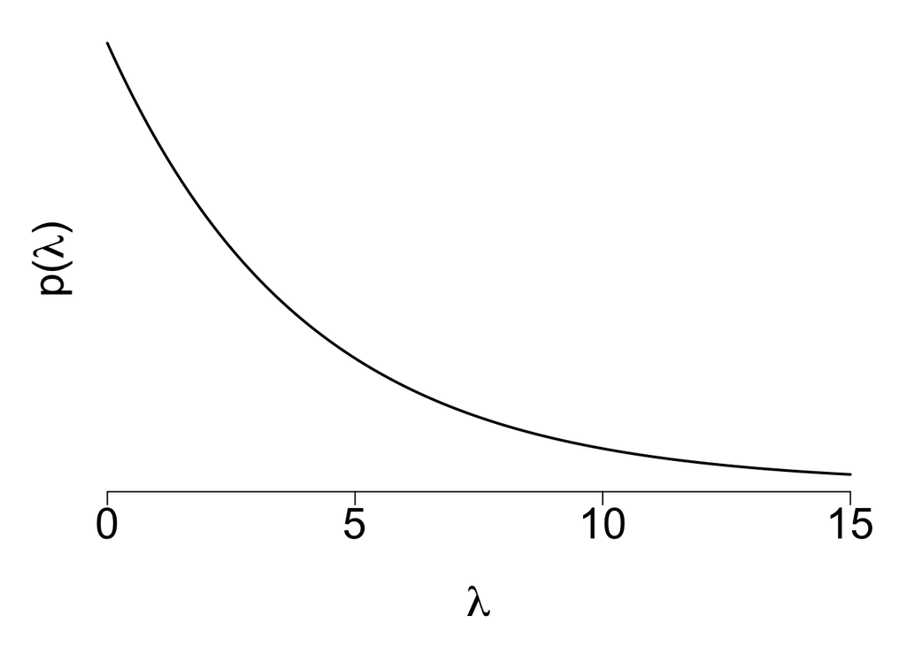

```r
# Plot the prior distribution
L = seq(0, 15, length.out = 1000)
par(mar = c(6, 3, 1, 1), las = 1)
plot(L, dgamma(L, shape = s, rate = r), type = "l", axes = FALSE,
     xlab = "", ylab = "", xlim = c(0, 15),
     lwd = 2)
mtext(expression(lambda), side = 1, line = 4, cex = 2)
mtext(expression(paste("p(", lambda, ")")), side = 2, line = 0, cex = 2, las = 0)
axis(1, cex.axis = 2)
```

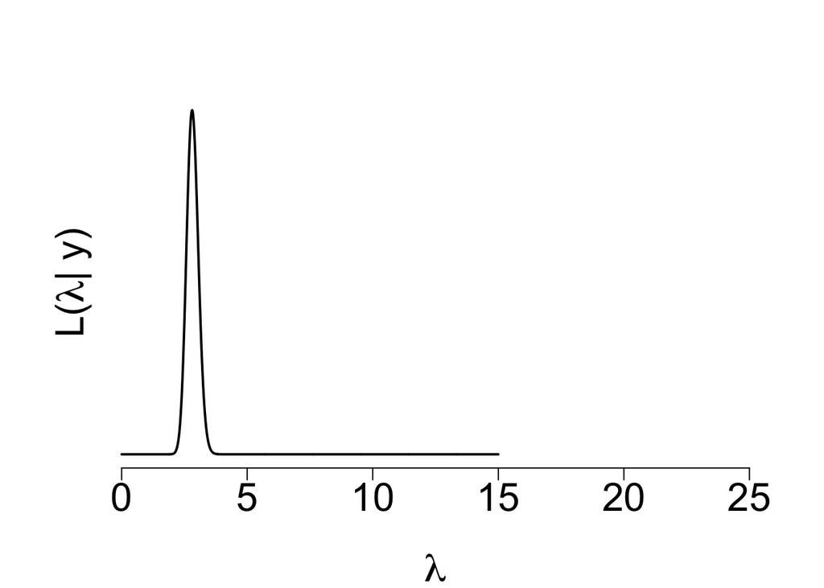

```r
# Plot the likelihood function
likelihood = sapply(L, function(l) {
  prod(dpois(x, lambda = l))
})

plot(L, likelihood, type = "l", axes = FALSE,
     xlab = "", ylab = "", xlim = c(0, 25),
     lwd = 2)
mtext(expression(lambda), side = 1, line = 4, cex = 2)
mtext(expression(paste("L(", lambda, "| y)")), side = 2, line = 0, cex = 2, las = 0)
axis(1, cex.axis= 2)
```

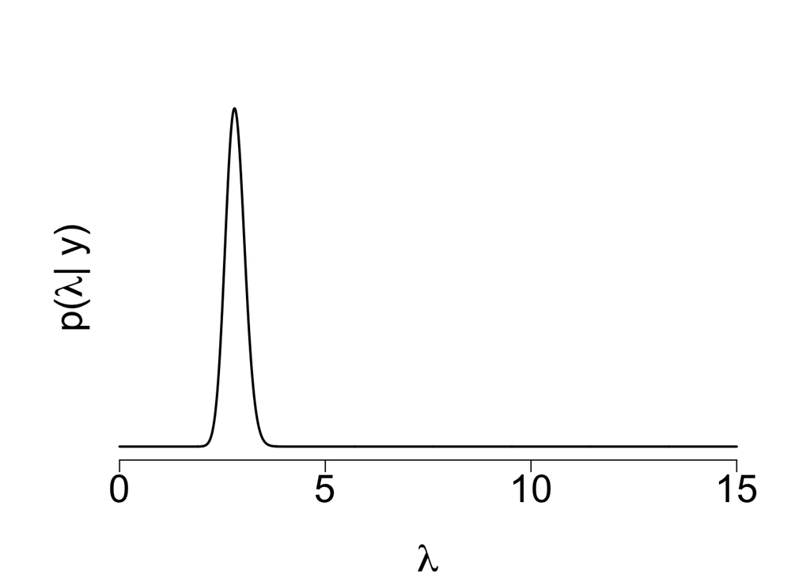

```r
# Plot the posterior distribution
plot(L, dgamma(L, shape = s_post, rate = r_post), type = "l", axes = FALSE,
     xlab = "", ylab = "", xlim = c(0, 15),
     lwd = 2)
mtext(expression(lambda), side = 1, line = 4, cex = 2)
mtext(expression(paste("p(", lambda, "| y)")), side = 2, line = 0, cex = 2, las = 0)
axis(1, cex.axis= 2)
```

We started with a relatively diffuse prior on the expected number of goals. We anticipated roughly four goals per game. We observed an average of 2.8 goals per game. The likelihood was very peaked, thus given our relatively vague prior, the posterior was peaked too with a mean 2.81 close to the sample average.

## Exercise 5.8

In each situation below, we observe the outcomes for a Normal random sample, $Y_i | \mu \overset{\text{ind}}{\sim} N (\mu , \sigma^2 )$ with known $\sigma$. Specify and plot the corresponding likelihood function of $\mu$.

1. $(y_1, y_2, y_3) = (-4.3 , 0.7 , -19.4 )$ and $\sigma = 10$

**Solution**  
We are given the data $y = (-4.3, 0.7, -19.4)$, and we are asked to plot the likelihood function assuming a fixed standard deviation $\sigma = 10$.

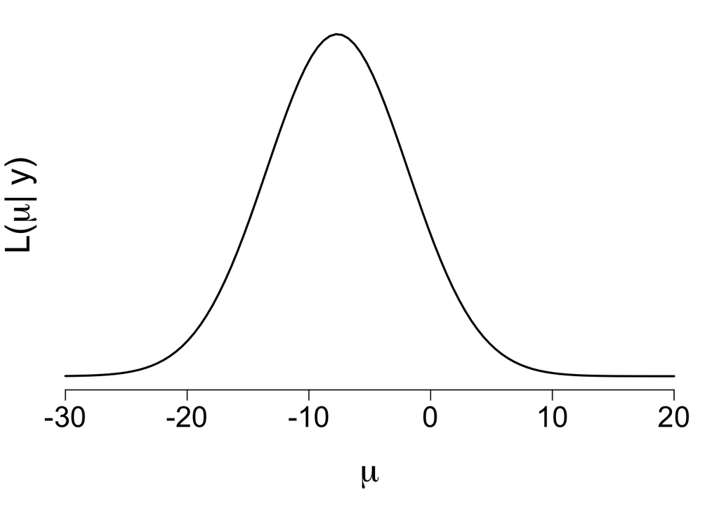

```r
# Given data
y = c(-4.3, 0.7, -19.4)

# Generate a range of mu values
M = seq(-30, 20, length.out = 100)

# Compute the likelihood for each mu
likelihood = sapply(M, function(m) {
  prod(dnorm(y, mean = m, sd = 10))
})

# Plot the likelihood function
par(mar = c(6, 2, 1, 1), las = 1)
plot(M, likelihood, type = "l", axes = FALSE,
     xlab = "", ylab = "", xlim = c(min(M), max(M)),
     lwd = 2)
mtext(expression(mu), side = 1, line = 4, cex = 2)
mtext(expression(paste("L(", mu, "| y)")), side = 2, line = 0, cex = 2, las = 0)
axis(1, cex.axis = 1.7, at = c(-30, -20, -10, 0, 10, 20))
```

2. $(y_1, y_2, y_3, y_4) = (-12 , 1.2 , -4.5 , 0.6 )$ and $\sigma = 6$

**Solution**  
We are given the data $y = (-12, 1.2, -4.5, 0.6)$, and we are asked to plot the likelihood function assuming a fixed standard deviation $\sigma = 6$.

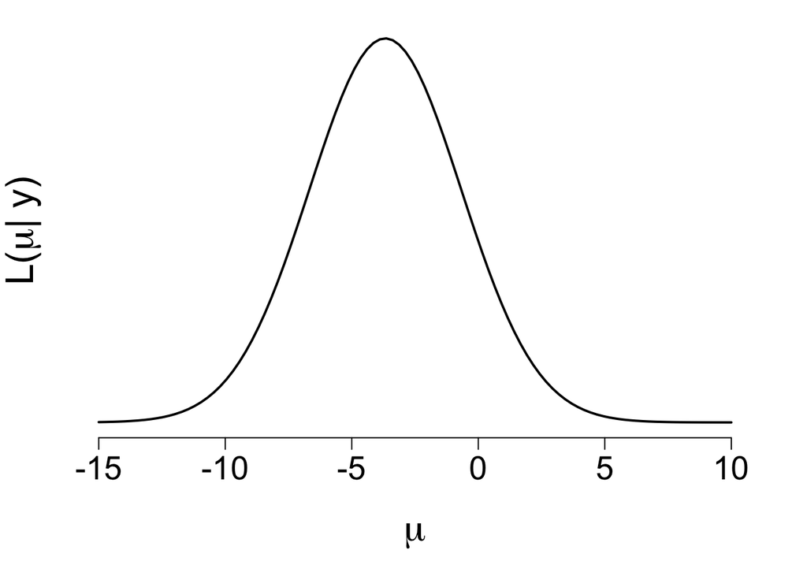

```r
# Given data
y = c(-12, 1.2, -4.5, 0.6)

# Generate a range of mu values
M = seq(-15, 10, length.out = 100)

# Compute the likelihood for each mu
likelihood = sapply(M, function(m) {
  prod(dnorm(y, mean = m, sd = 6))
})

# Plot the likelihood function
par(mar = c(6, 2, 1, 1), las = 1)
plot(M, likelihood, type = "l", axes = FALSE,
     xlab = "", ylab = "", xlim = c(-16, 11),
     lwd = 2)
mtext(expression(mu), side = 1, line = 4, cex = 2)
mtext(expression(paste("L(", mu, "| y)")), side = 2, line = 0, cex = 2, las = 0)
axis(1, cex.axis = 1.7, at = c(-15, -10, -5, 0, 5, 10))
```

3. $(y_1, y_2) = (12.4 , 6.1 )$ and $\sigma = 5$

**Solution**  
We are given the data $y = (12.4 , 6.1)$, and we are asked to plot the likelihood function assuming a fixed standard deviation $\sigma = 5$.

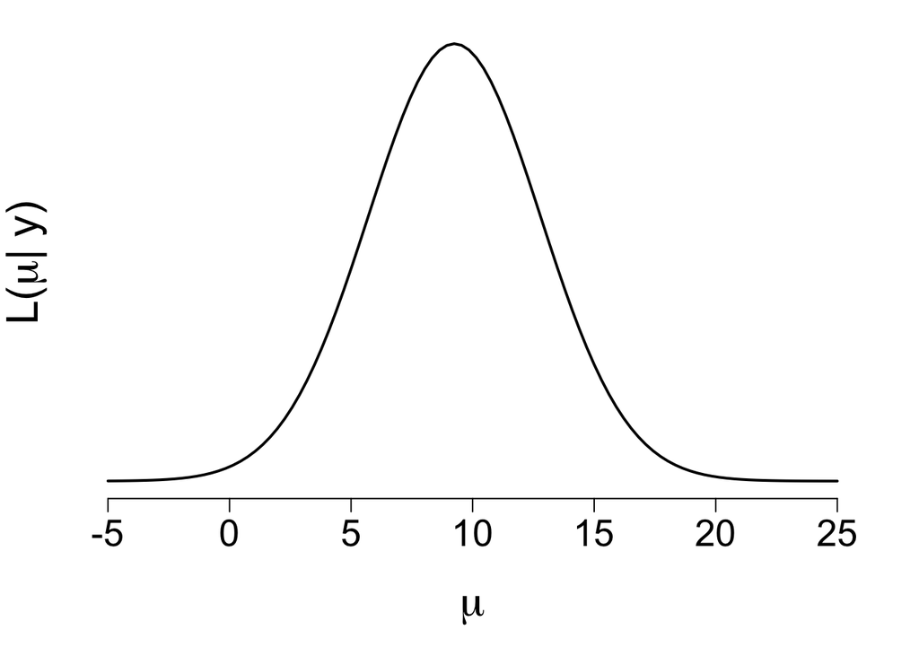

```r
# Given data
y = c(12.4, 6.1)

# Generate a range of mu values
M = seq(-5, 25, length.out = 100)

# Compute the likelihood for each mu
likelihood = sapply(M, function(m) {
  prod(dnorm(y, mean = m, sd = 5))
})

# Plot the likelihood function
par(mar = c(6, 2, 1, 1), las = 1)
plot(M, likelihood, type = "l", axes = FALSE,
     xlab = "", ylab = "", xlim = c(-6, 26),
     lwd = 2)
mtext(expression(mu), side = 1, line = 4, cex = 2)
mtext(expression(paste("L(", mu, "| y)")), side = 2, line = 0, cex = 2, las = 0)
axis(1, cex.axis = 1.7, at = c(-5, 0, 5, 10, 15, 20, 25))
```

4. $(y_1, y_2, y_3, y_4, y_5) = (1.6 , 0.09 , 1.7 , 1.1 , 1.1 )$ and $\sigma = 0.6$

**Solution**  
We are given the data $y = (1.6, 0.09, 1.7, 1.1, 1.1)$, and we are asked to plot the likelihood function assuming a fixed standard deviation $\sigma = 0.6$.

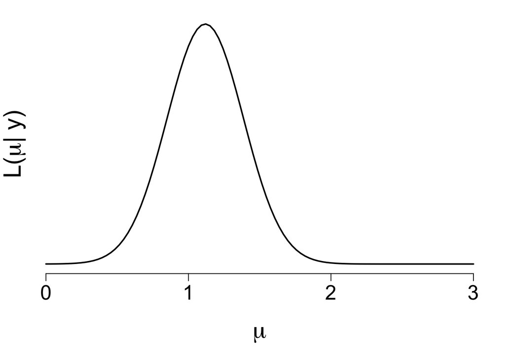

```r
# Given data
y = c(1.6, 0.09, 1.7, 1.1, 1.1)

# Generate a range of mu values
M = seq(0, 3, length.out = 100)

# Compute the likelihood for each mu
likelihood = sapply(M, function(m) {
  prod(dnorm(y, mean = m, sd = 0.6))
})

# Plot the likelihood function
par(mar = c(6, 2, 1, 1), las = 1)
plot(M, likelihood, type = "l", axes = FALSE,
     xlab = "", ylab = "", xlim = c(0, 3),
     lwd = 2)
mtext(expression(mu), side = 1, line = 4, cex = 2)
mtext(expression(paste("L(", mu, "| y)")), side = 2, line = 0, cex = 2, las = 0)
axis(1, cex.axis = 1.7, at = c(0,1,2,3))
```

## Exercise 5.9

You just bought stock in FancyTech. Let random variable $\mu$ be the average dollar amount that your FancyTech stock goes up or down in a one-day period. At first, you believe that $\mu$ is 7.2 dollars with a standard deviation of 2.6 dollars.

1. Tune and plot an appropriate Normal prior model for $\mu$.

**Solution**  
We are given a **Normal prior** for $\mu$ with a **mean** of 7.2 and a **standard deviation** of 2.6. We will plot the probability density function (PDF) of this distribution.

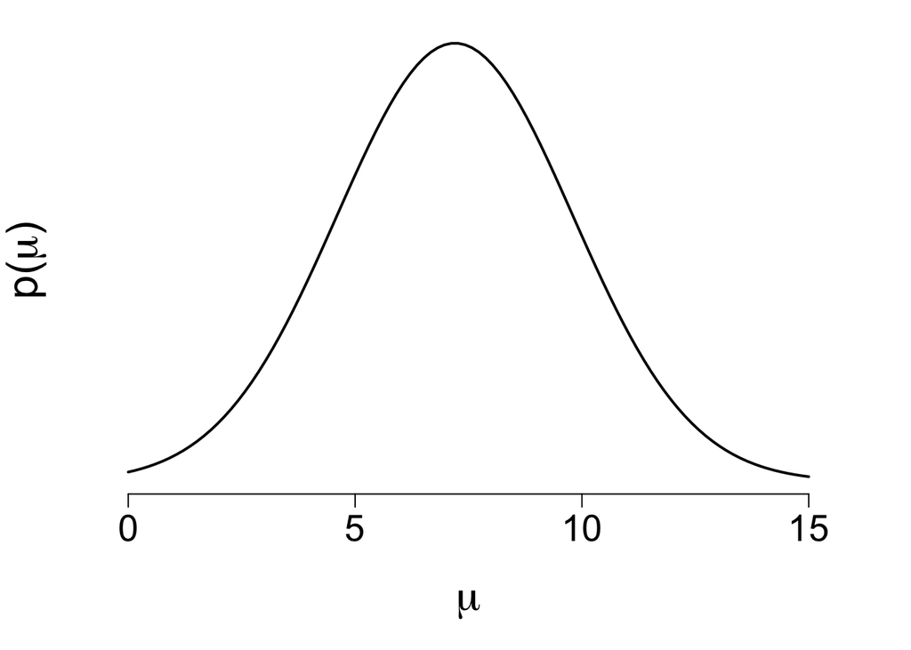

```r
# Define the range of mu values
mu = seq(0, 15, length.out = 100)

# Plot the Normal distribution
par(mar = c(6, 2, 1, 1), las = 1)
plot(mu, dnorm(mu, mean = 7.2, sd = 2.6), type = "l", axes = FALSE,
     xlab = "", ylab = "", xlim = c(-1, 16),
     lwd = 2)
mtext(expression(mu), side = 1, line = 4, cex = 2)
mtext(expression(paste("p(", mu, ")")), side = 2, line = 0, cex = 2, las = 0)
axis(1, cex.axis = 1.7, at = c(0, 5, 10, 15))
```

2. According to your plot, does it seem plausible that the FancyTech stock would increase by an average of 7.6 dollars in a day?

**Solution** We can use a vertical line on the plot to represent the value $\mu=7.6$. This will help us assess the plausibility visually.

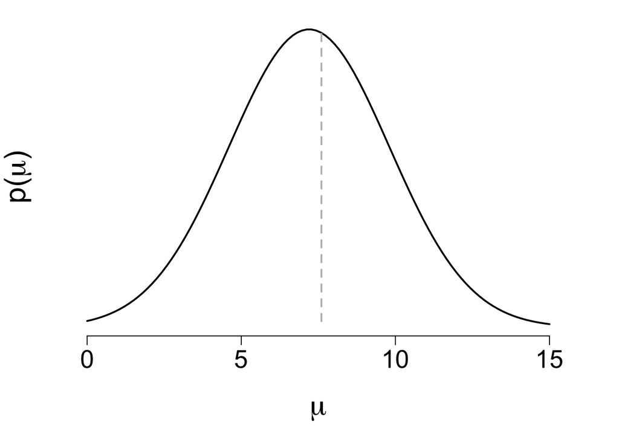

```r
# Define the range of mu values
mu = seq(0, 15, length.out = 100)

# Plot the Normal distribution
par(mar = c(6, 2, 1, 1), las = 1)
plot(mu, dnorm(mu, mean = 7.2, sd = 2.6), type = "l", axes = FALSE,
     xlab = "", ylab = "", xlim = c(-1, 16),
     lwd = 2)
mtext(expression(mu), side = 1, line = 4, cex = 2)
mtext(expression(paste("p(", mu, ")")), side = 2, line = 0, cex = 2, las = 0)
axis(1, cex.axis = 1.7, at = c(0, 5, 10, 15))

# Plot the Normal distribution
library(plotrix)
ablineclip(v = 7.6,
           lty = 2,
           lwd = 2,
           col = "gray",
           y1 = 0,
           y2 = dnorm(7.6, mean = 7.2, sd = 2.6))
```

So yes, I assume it to be very plausible.

3. Does it seem plausible that the FancyTech stock would increase by an average of 4 dollars in a day?

**Solution** We can use a vertical line on the plot to represent the value $\mu = 4$. This will help us assess the plausibility visually.

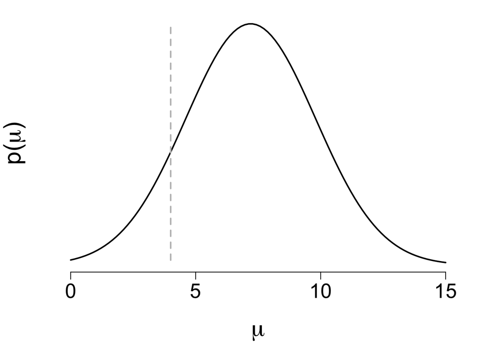

```r
# Define the range of mu values
mu = seq(0, 15, length.out = 100)

# Plot the Normal distribution
par(mar = c(6, 2, 1, 1), las = 1)
plot(mu, dnorm(mu, mean = 7.2, sd = 2.6), type = "l", axes = FALSE,
     xlab = "", ylab = "", xlim = c(-1, 16),
     lwd = 2)
mtext(expression(mu), side = 1, line = 4, cex = 2)
mtext(expression(paste("p(", mu, ")")), side = 2, line = 0, cex = 2, las = 0)
axis(1, cex.axis = 1.7, at = c(0, 5, 10, 15))

# Plot the Normal distribution
library(plotrix)
ablineclip(v = 4,
           lty = 2,
           lwd = 2,
           col = "gray",
           y1 = 0,
           y2 = dnorm(7.6, mean = 7.2, sd = 2.6))
```

Yes, this is plausible.

4. What is the prior probability that, on average, the stock price goes down? Hint: `pnorm()`.

**Solution** The probability that the stock will go down corresponds to the area under the Normal distribution curve to the left of $\mu = 0$. We can compute this probability using the **CDF** (Cumulative Distribution Function) of the Normal distribution.

```r
pnorm(0, mean = 7.2, sd = 2.6)
```

```
## [1] 0.002809441
```

This is the **prior probability** that the stock will go down (i.e., have a negative change).

5. What is the prior probability that, on average, your stock price goes up by more than 8 dollars per day?

**Solution** To calculate the probability that the stock will go up by more than 8 dollars, we use the **CDF** for $\mu = 8$ but set `lower.tail = FALSE` to get the probability of the upper tail.

```r
pnorm(8, mean = 7.2, sd = 2.6, lower.tail = FALSE)
```

```
## [1] 0.3791582
```

This is the **prior probability** that the stock will go up by more than 8 dollars.

## Exercise 5.10

Continuing with Exercise 5.9, it’s reasonable to assume that the daily changes in FancyTech stock value are Normally distributed around an unknown mean of $\mu$ with a known standard deviation of $\sigma = 2$ dollars. On a random sample of 4 days, you observe changes in stock value of -0.7, 1.2, 4.5, and -4 dollars.

1. Plot the corresponding likelihood function of $\mu$.

**Solution:**  
We are given a dataset $x = (-0.7, 1.2, 4.5, -4)$, and we are asked to plot the likelihood function assuming a **standard deviation** $\sigma = 2$. The likelihood function is based on the **Normal distribution**:

$$L(\mu | x) = \prod_{i=1}^n \frac{1}{\sqrt{2\pi \sigma^2}} e^{-\frac{(x_i
- \mu)^2}{2\sigma^2}}$$

We will calculate the likelihood for different values of $\mu$ and plot it.

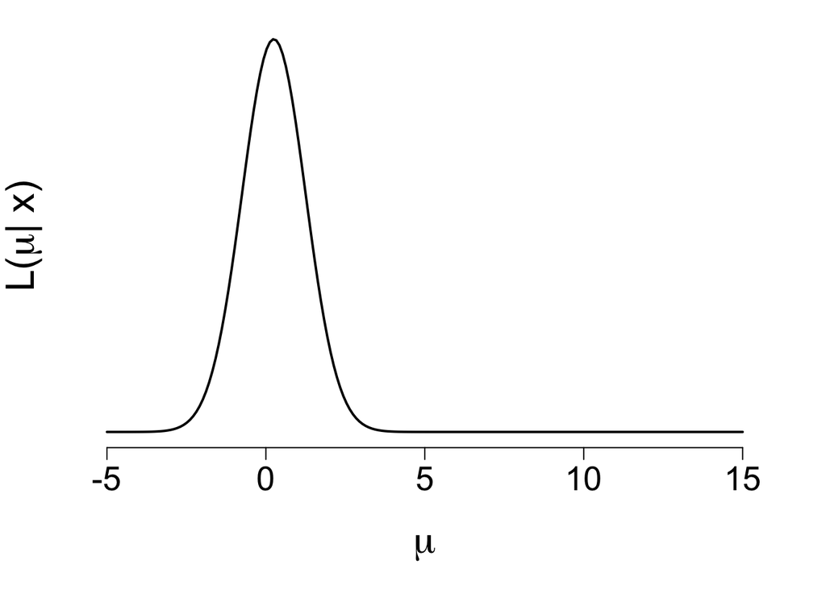

```r
# Given data
x = c(-0.7, 1.2, 4.5, -4)

# Generate a range of mu values
M = seq(-5, 15, length.out = 200)

# Compute the likelihood for each mu
likelihood = sapply(M, function(m) {
  prod(dnorm(x, mean = m, sd = 2))
})

# Plot the likelihood function
par(mar = c(6, 2, 1, 1), las = 1)

plot(M, likelihood, type = "l", axes = FALSE,
     xlab = "", ylab = "", xlim = c(-6, 16),
     lwd = 2)
mtext(expression(mu), side = 1, line = 4, cex = 2)
mtext(expression(paste("L(", mu, "| x)")), side = 2, line = 0, cex = 2, las = 0)
axis(1, cex.axis = 1.7, at = c(-5, 0, 5, 10, 15))
```

2. Plot the prior pdf, likelihood function, and the posterior pdf for $\mu$.

We will plot the **prior**, **likelihood**, and **posterior** distributions for $\mu$. First, let’s plot the **prior** distribution using the Normal distribution with $\mu = 7.2$ and $\sigma = 2.6$.

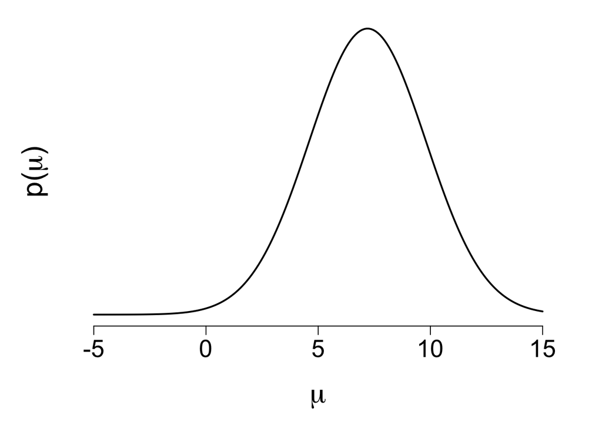

```r
# Plotting the prior distribution for mu
par(mar = c(6, 3, 1, 1), las = 1)
plot(M, dnorm(M, mean = 7.2, sd = 2.6), type = "l", axes = FALSE,
     xlab = "", ylab = "", xlim = c(-6, 16),
     lwd = 2)
mtext(expression(mu), side = 1, line = 4, cex = 2)
mtext(expression(paste("p(", mu, ")")), side = 2, line = 0, cex = 2, las = 0)
axis(1, cex.axis = 1.7, at = c(-5, 0, 5, 10, 15))
```

### Posterior Distribution

The posterior distribution can be calculated using the **Normal-Normal conjugacy**. The posterior mean and standard deviation are:

- **Posterior Mean**:
  $$\text{Posterior Mean} = \frac{\theta \cdot \sigma^2}{n \cdot \tau^2 +
  \sigma^2} + \frac{\bar{y} \cdot n \cdot \tau^2}{n \cdot \tau^2 +
  \sigma^2}$$
- **Posterior SD**:
  $$\text{Posterior SD} = \sqrt{\frac{\tau^2 \sigma^2}{n \cdot \tau^2 +
  \sigma^2}}$$

where:

- $\theta = 7.2$ (prior mean),
- $\sigma = 2$ (standard deviation),
- $n = 4$ (number of observations),
- $\tau^2 = 6.76$ (prior variance).

We compute the posterior mean and standard deviation and plot the posterior distribution:

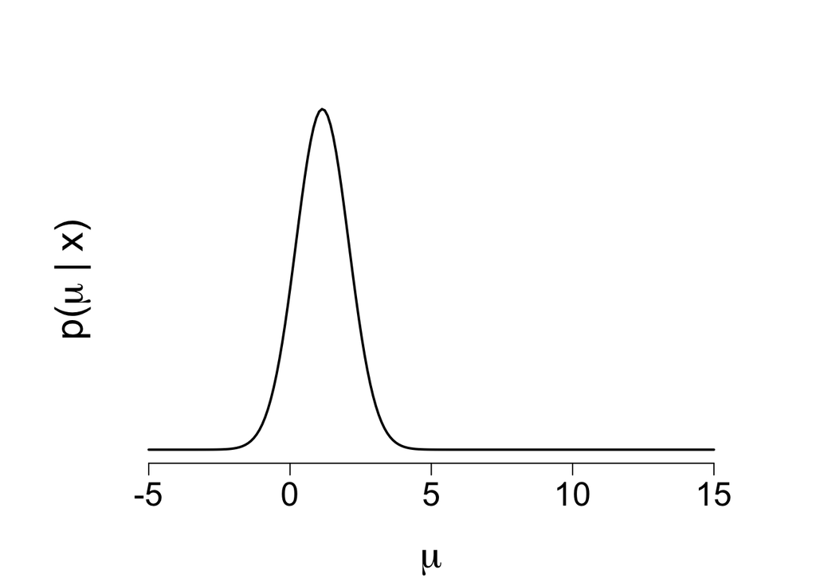

```r
# Prior parameters
n = 4
tau2 = 6.76
sigma2 = 4
theta = 7.2

# Calculate posterior parameters
post.mean = theta * sigma2 / (n * tau2 + sigma2) + mean(x) * n * tau2 / (n * tau2 + sigma2)
post.sd = sqrt(tau2 * sigma2 / (n * tau2 + sigma2))

# Plot the posterior distribution
plot(M, dnorm(M, mean = post.mean, sd = post.sd), type = "l", axes = FALSE,
     xlab = "", ylab = "", xlim = c(-6, 16),
     lwd = 2)
mtext(expression(mu), side = 1, line = 4, cex = 2)
mtext(expression(paste("p(", mu, " | x)")), side = 2, line = 0, cex = 2, las = 0)
axis(1, cex.axis = 1.7, at = c(-5, 0, 5, 10, 15))
```

3. Use `summarize_normal_normal()` to calculate descriptive statistics for the prior and the posterior models.

**Solution:**  
We will use the **`bayesrules`** package to summarize the posterior distribution for $\mu$. This function takes the **prior mean**, **prior standard deviation**, **observed mean**, and **sample size** to compute the **posterior distribution**.

```r
# Load the bayesrules package
library(bayesrules)

# Summarize the Normal-Normal posterior using bayesrules
summarize_normal_normal(mean = 7.2,
                        sd = 2.6,
                        sigma = 2, # prior standard deviation
                        y_bar = mean(x), # observed mean
                        n = length(x)) # sample size
```

```
##       model     mean     mode      var        sd
## 1     prior 7.200000 7.200000 6.760000 2.6000000
## 2 posterior 1.145619 1.145619 0.871134 0.9333456
```

4. Comment on how your understanding about $\mu$ evolved from the prior (in the previous exercise) to the posterior based on the observed data.
5. What is the posterior probability that, on average, the stock price goes down? Hint: `pnorm()`.

**Solution** The probability that the stock will go down corresponds to the area under the Normal distribution curve to the left of $\mu = 0$. We can compute this probability using the **CDF** (Cumulative Distribution Function) of the Normal distribution.

```r
# Prior parameters
n = 4
tau2 = 6.76
sigma2 = 4
theta = 7.2

# Calculate posterior parameters
post.mean = theta * sigma2 / (n * tau2 + sigma2) + mean(x) * n * tau2 / (n * tau2 + sigma2)
post.sd = sqrt(tau2 * sigma2 / (n * tau2 + sigma2))

pnorm(0, mean = post.mean, sd = post.sd)
```

```
## [1] 0.1098301
```

This is the **posterior probability** that the stock will go down (i.e., have a negative change).

6. What is the posterior probability that, on average, your stock price goes up by more than 8 dollars per day?

**Solution** To calculate the probability that the stock will go up by more than 8 dollars, we use the **CDF** for $\mu = 8$ but set `lower.tail = FALSE` to get the probability of the upper tail.

```r
# Prior parameters
n = 4
tau2 = 6.76
sigma2 = 4
theta = 7.2

# Calculate posterior parameters
post.mean = theta * sigma2 / (n * tau2 + sigma2) + mean(x) * n * tau2 / (n * tau2 + sigma2)
post.sd = sqrt(tau2 * sigma2 / (n * tau2 + sigma2))

pnorm(8, mean = post.mean, sd = post.sd, lower.tail = FALSE)
```

```
## [1] 1.037418e-13
```

This is the **posterior probability** that the stock will go up by more than 8 dollars.